# Image classifier to detect architecture types in buildings

*(This notebook is cloned version of Jeremy Howard's fastai lesson)*

In this exercise, we build an image classifier to identify building architecture using fast.ai library built on pytorch. We also use pyimagesearch to procure datasets from google images.

The type of building architectures considered for this work are gothic and renaissance. Gothic style flourished in Europe until 16th century. It was predominantly used to contruct cathedrals and churches whereas renaissance architecture prevailed in 17th century folowing the gothic era. To an untrained eye, its extremely diffcult to differentiate between the two. As a first step, we leverage the capabilities of AI and train a pre-trained ResNet34 model to learn the intricacies of both styles and aid us in differentiating the same.

### Creating our own dataset from Google images

- Step 1 is to search for the images we are interested in Google Images. We scroll down until there is a good collection of images in the result.
- Step 2 is to open the java script console using the following short  
  `Ctrl``Shift``J` in Windows/Linux `Cmd``Opt``J` in Mac
- Step 3 is to paste the following command to get a list of urls of those images

  ```
  urls = Array.from(document.querySelectorAll('.rg_di .rg_meta')).map(el=>JSON.parse(el.textContent).ou);
  window.open('data:text/csv;charset=utf-8,' + escape(urls.join('\n')));
  ```

If the above approach doesn't work, follow this [link](https://www.pyimagesearch.com/2017/12/04/how-to-create-a-deep-learning-dataset-using-google-images/) by Adrian Rosebrock

### Import the necessary libraries

We import the fast.ai library, followed by creating folders in our server for the downloaded data which resides in our local machine.

```python
from fastai import *
from fastai.vision import *
```

```python
folder = 'gothic'
file = 'gothic.txt'
```

```python
folder = 'renaissance'
file = 'renaissance.txt'
```

```python
path = Path('data/architectures')
dest = path/folder
dest.mkdir(parents=True, exist_ok=True)
```

Finally, upload your urls file. You just need to press 'Upload' in your working directory and select your file, then click 'Upload' for each of the displayed files.

[figure not shown]

### Download images into our server

```python
classes = ['gothic','renaissance']
```

```python
download_images(path/file, dest, max_pics=200)
```

100.00% [200/200 00:12<00:00]

[output not shown]

Then we can remove any images that can't be opened: Check for corrupted images in every batch and do the needful.

```python
for c in classes:
    print(c)
    verify_images(path/c, delete=True, max_workers=8)
```

```
gothic
```

100.00% [191/191 00:05<00:00]

```
renaissance
```

100.00% [192/192 00:03<00:00]

```
cannot identify image file '/home/jupyter/tutorials/fastai/course-v3/nbs/dl1/data/architectures/renaissance/00000191.jpg'
cannot identify image file '/home/jupyter/tutorials/fastai/course-v3/nbs/dl1/data/architectures/renaissance/00000184.jpg'
cannot identify image file '/home/jupyter/tutorials/fastai/course-v3/nbs/dl1/data/architectures/renaissance/00000164.jpg'
cannot identify image file '/home/jupyter/tutorials/fastai/course-v3/nbs/dl1/data/architectures/renaissance/00000151.jpg'
```

### Overview of the dataset

```python
np.random.seed(10)
data = ImageDataBunch.from_folder(path, train=".", valid_pct=0.2,
        ds_tfms=get_transforms(), size=224, num_workers=4).normalize(imagenet_stats)
```

Good! Let's take a look at some of our pictures then.

```python
data.classes
```

```
['gothic', 'renaissance']
```

[figure not shown]

```python
data.show_batch(rows=3, figsize=(7,8))
```

```python
data.classes, data.c, len(data.train_ds), len(data.valid_ds)
```

```
(['gothic', 'renaissance'], 2, 295, 84)
```

### Train model

We go ahead and create a convolutional neural network on our dataset. We use a resnet34 pre-trained model and print out the error rate for each epoch. For starters, we set number of epochs to 5.

```python
learn = create_cnn(data, models.resnet34, metrics=error_rate)
```

```python
learn.fit_one_cycle(5)
```

```
Total time: 01:08
epoch  train_loss  valid_loss  error_rate
1      0.720836    0.465196    0.178571    (00:13)
2      0.548726    0.359956    0.142857    (00:13)
3      0.430237    0.371422    0.119048    (00:13)
4      0.365127    0.412312    0.130952    (00:13)
5      0.317627    0.423103    0.119048    (00:15)
```

```python
learn.save('building-stage-1')
```

```python
learn.unfreeze()
```

```python
learn.lr_find()
```

```
LR Finder complete, type {learner_name}.recorder.plot() to see the graph.
```

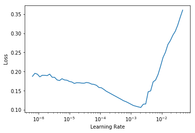

```python
learn.recorder.plot()
```

```python
learn.fit_one_cycle(5, max_lr=slice(3e-5,3e-3))
```

```
Total time: 01:07
epoch  train_loss  valid_loss  error_rate
1      0.242447    0.623199    0.154762    (00:15)
2      0.183917    0.842221    0.142857    (00:11)
3      0.178701    0.601939    0.107143    (00:13)
4      0.141692    0.471145    0.095238    (00:14)
5      0.130683    0.441080    0.095238    (00:13)
```

```python
learn.save('building-stage-2')
```

### Interpretation

Plotting a confusion matrix to understand misclassfied examples

```python
learn.load('building-stage-2')
```

```python
interp = ClassificationInterpretation.from_learner(learn)
```

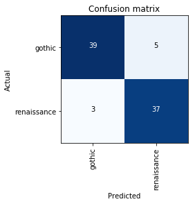

```python
interp.plot_confusion_matrix()
```

### Cleaning Up

Some of our top losses aren't due to bad performance by our model. There are images in our data set that shouldn't be.

Using the `FileDeleter` widget from `fastai.widgets` we can prune our top losses, removing photos that don't belong.

First we need to get the file paths from our top_losses. Here's a handy function that pulls out all our top_losses:

```python
from fastai.widgets import *

losses,idxs = interp.top_losses()
top_loss_paths = data.valid_ds.x[idxs]
```

Now we can pass in these paths to our widget.

```python
fd = FileDeleter(file_paths=top_loss_paths)
```

Flag photos for deletion by clicking 'Delete'. Then click 'Confirm' to delete flagged photos and keep the rest in that row. The `File_Deleter` will show you a new row of images until there are no more to show. In this case, the widget will show you images until there are none left from `top_losses`.

### Making the model production ready

```python
data.classes
```

```
['gothic', 'renaissance']
```

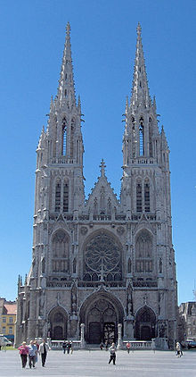

```python
img = open_image(path/'gothic'/'00000011.jpg')
img
```

[figure not shown]

```python
img = open_image(path/'renaissance'/'00000011.jpg')
img
```

```python
classes = ['gothic','renaissance']
data2 = ImageDataBunch.single_from_classes(path, classes, tfms=get_transforms(), size=224).normalize(imagenet_stats)
learn = create_cnn(data2, models.resnet34)
learn.load('building-stage-2')
```

```python
pred_class,pred_idx,outputs = learn.predict(img)
pred_class
```

[output not shown]

### Future work

- Collect more images for each class by excluding irrelevant images, expand the dataset
- Fine tune LR and Epochs
- Extend this work for more architectures styles